# Homicídios Dolosos na cidade de São Paulo

Caio Martins

Com alguma frequência os noticiários reportam informações sobre os dados criminais na cidade de São Paulo, porém muitas vezes não informam quais são as regiões da cidade mais/menos vulneráveis a cada tipo de ocorrência.

A Folha de SP, por exemplo, noticiou no dia 26 de Janeiro de 2023 que a [“Cidade de São Paulo tem o menor número de assassinatos em 20 anos”](https://www1.folha.uol.com.br/cotidiano/2023/01/cidade-de-sao-paulo-tem-o-menor-numero-de-assassinatos-em-20-anos.shtml). Contudo, a reportagem não informa quais são as regiões de São Paulo que registram as maiores ocorrências.

O G1 noticiou que os [homícidios aumentaram 4,7% em 2022](https://g1.globo.com/sp/sao-paulo/noticia/2023/01/26/homicidios-aumentam-47percent-e-estupros-19percent-no-estado-de-sp-em-2022-latrocinios-cairam-73percent.ghtml). A matéria também informa que a cidade de São Paulo teve alta nos crimes de roubos e furtos em geral. Mais uma vez, a reportagem não diz nada a respeito de quais são as regiões que mais registram casos.

O Uol também noticiou que a cidade de São Paulo apresentou [queda na taxa de homícidios e aumento no número de roubos](https://noticias.uol.com.br/cotidiano/ultimas-noticias/2022/07/25/dados-ssp-criminalidade-sao-paulo.htm) Novamente, não é informado em detalhes quais são as localidades mais propensas a registrar tais ocorrências.

Este “estudo” irá analisar apenas os casos de homicídios dolosos. Será apresentado de maneira geral a evolução do número de homicídios dolosos na cidade de São Paulo nos últimos anos (2017-2022), assim como as regiões que mais registram esse tipo de ocorrência. Ao final, haverá um mapa interativo com as localizações reais dos crimes de homicídios dolosos na cidade de SP.

Quais os meses que apresentam maiores taxas de ocorrência ? Quais são as regiões que mais registram ocorrências de homicídios dolosos ? Houve uma diminuição nos últimos anos ? Pretendo responder estas perguntas nesta breve análise.

### Metodologia

Os dados foram extraídos no Portal da Transparência no site da [Secretaria de Segurança Pública de São Paulo](http://www.ssp.sp.gov.br/transparenciassp/Default.aspx)

Os dados fornecidos pela Secretaria limitam-se ao anos 2017-2022, e por isso a análise será deste ciclo temporal.

A análise foi realizada com a linguagem R. Todo o código utilizado para gerar esse estudo pode ser encontrado no meu [github](https://github.com/martinscaio/Homicidios-Dolosos)

#### Evolução do Nº de vítimas de homicídios dolosos nos últimos anos

[interactive chart not shown]

Como podemos observar há um declínio no número de vítimas de homicídios dolosos nos últimos anos.  
O ano de 2022 registrou 582 casos, o menor registro dos últimos 5 anos.

E se quebrarmos os dados por mes/ano ?!

#### Comparativo do Nº de vítimas de homicídios dolosos por mês/ano na cidade de SP

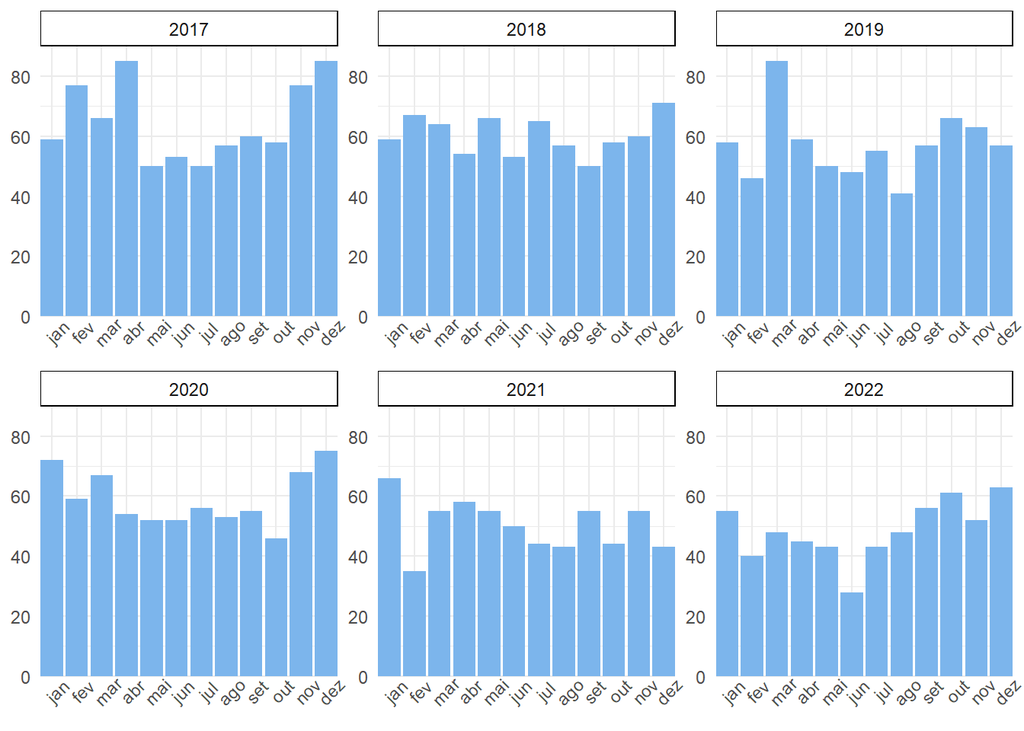

##### Tabela com o número de casos por mês/ano

| Mês | 2017 | 2018 | 2019 | 2020 | 2021 | 2022 |
| --- | --- | --- | --- | --- | --- | --- |
| Janeiro | 59 | 59 | 58 | 72 | 66 | 55 |
| Fevereiro | 77 | 67 | 46 | 59 | 35 | 40 |
| Março | 66 | 64 | 85 | 67 | 55 | 48 |
| Abril | 85 | 54 | 59 | 54 | 58 | 45 |
| Maio | 50 | 66 | 50 | 52 | 55 | 43 |
| Junho | 53 | 53 | 48 | 52 | 50 | 28 |
| Julho | 50 | 65 | 55 | 56 | 44 | 43 |
| Agosto | 57 | 57 | 41 | 53 | 43 | 48 |
| Setembro | 60 | 50 | 57 | 55 | 55 | 56 |
| Outubro | 58 | 58 | 66 | 46 | 44 | 61 |
| Novembro | 77 | 60 | 63 | 68 | 55 | 52 |
| Dezembro | 85 | 71 | 57 | 75 | 43 | 63 |

Foi em Junho de 2022 o menor registro de vítimas de homicídios dolosos na cidade dos últimos 5 anos. Dezembro de 2022 registrou 20 casos a mais que em dezembro de 2021, porém numa perspectiva comparada é bem abaixo do que costumava ser em anos como 2017 e 2018.

### Quais são as Delegacias que mais/menos registram ocorrências ?

Vamos utilizar os distritos policiais como proxy para o bairro. Assim, é possível estimar quais são as regiões de SP mais vulneráveis a esse tipo de ocorrência

Abaixo uma tabela com o número vítimas de Homicídios Dolosos (2017-2022) por Delegacia/Distrito policial. É possível ordenar descendente/ascendente clicando em cada ano. Também é possível pesquisar pelo nome caso queira.

|  | Delegacia | 2017 | 2018 | 2019 | 2020 | 2021 | 2022 |
| --- | --- | --- | --- | --- | --- | --- | --- |
| 1 | 001 DP - Sé | 18 | 15 | 15 | 14 | 13 | 13 |
| 2 | 002 DP - Bom Retiro | 5 | 7 | 3 | 4 | 1 | 7 |
| 3 | 003 DP - Campos Elíseos | 9 | 7 | 7 | 5 | 9 | 12 |
| 4 | 004 DP - Consolação | 2 | 2 | 3 | 2 | 2 | 0 |
| 5 | 005 DP - Aclimação | 6 | 3 | 5 | 1 | 1 | 4 |
| 6 | 006 DP - Cambuci | 3 | 2 | 1 | 3 | 3 | 3 |
| 7 | 007 DP - Lapa | 3 | 5 | 10 | 4 | 1 | 0 |
| 8 | 008 DP - Brás | 12 | 9 | 6 | 8 | 7 | 10 |
| 9 | 009 DP - Carandiru | 6 | 4 | 7 | 5 | 6 | 3 |
| 10 | 010 DP - Penha de França | 8 | 5 | 1 | 6 | 5 | 4 |

[output cut: 84 more lines]

### Análise Geoespacial

Um olhar geral sobre dos mapas georreferenciados de vítimas de homicídio na cidade de São Paulo entre 2017-2022

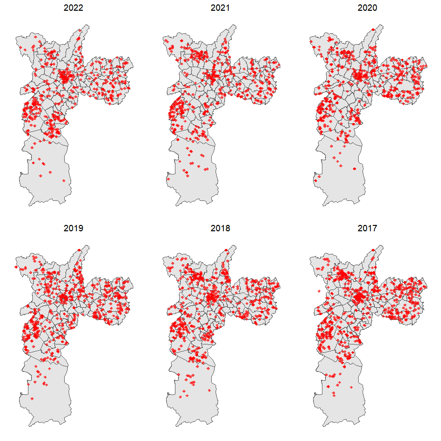

Vamos olhar de uma maneira mais detalhada para o ano de 2022

[interactive chart not shown]

Sabemos quais são os distritos policiais que mais registram vítimas de homicídio doloso, mas quais são as ruas/lugares em que essas ocorrências ocorreram ? Podemos plotar no OpenStreetMap as ocorrências para termos uma visão mais detalhada.

É possível aproximar, distanciar, interagir no mapa abaixo. Utilizei as Latitudes/Longitudes que a própria Secretaria disponibiliza nos dados da ocorrência

[interactive chart not shown]